# Introduction: Graphics and Principles of Data Visualisation

Seminar: Data Visualisation: Principles, Practices and Applications

Julia Schulte-Cloos

University of Marburg

November 9, 2026

✉️ julia.schulte-cloos@uni-marburg.de

# Welcome

## Hi there! 👋

### What’s your field of study?

### What’s your PhD about?

### Why are you interested in data vizualisation?

### Have you worked with `ggplot` before?

## What makes a good graph?

- 💬 Mindmap 💬
- 📊 Results 📊

#### 01_Graphics

What makes for a good data visualisation?

Please note up to five key characteristics that make for a good data visualisation.

[figure not shown]

[interactive chart not shown]

# Overview of the workshop

## Overview

1️⃣ Why Data Visualization?

2️⃣️ Foundations of the Grammar of Graphics

3️⃣️ Hands on - Fundamentals of ggplot

4️⃣ Advanced Visualizations

5️⃣ Hands on - Advanced ggplot applications

## Learning Outcomes

What can you expect to get out of this workshop?

**At the end of the workshop, you will be able to…**:

- Understand the principles of data visualization and best practices
- Comprehend the grammar of graphics for creating structured visualizations
- Apply the principles of `ggplot` to design effective data visualizations
- Readily create both simple and advanced visualizations
- Develop visualizations that incorporate maps and geospatial data
- Enhance your graphs and visualizations with advanced styling and textual elements
- Design interactive visualizations to engage your audience

## Course Materials & Logistics

### 🗓️ Schedule

- **Mon, Nov 9** (09:00 - 12:00) 💻 *Online*
- **Mon, Nov 16** (09:00 - 18:00) 📍 *In-person: AFL-E-003, Affolternstrasse 56, Cityport, EG*
- **Mon, Nov 23** (08:30 - 12:30) 💻 *Online*

### 🛠️ Tools & Materials

**Our toolkit:**

- **R & RStudio**
- **`tidyverse`** framework
- **`ggplot2`** for visualization

**Course Repository:** All code, data, and slides are available on GitHub: [🔗 jschultecloos/dataviz_2026](https://github.com/jschultecloos/dataviz_2026)

## Why visualizations?

> any effort to help people understand the significance of data by placing it in a visual context
- 🔍 **to explore your own data**
  - exploratory analysis
  - outlier detection
- 🗣️ **to communicate and report**
  - …clearly (using good design principles)
  - …precisely and accurately (a plot is worth 1000 words)
  - …effectively and efficiently
- 🎯 **purpose:** convey information and make a point (Wilke 2019)
- 🤐 …data rarely speaks for itself
- 📊 **to represent results of statistical analyses**

## Types of variables in data visualization scenarios

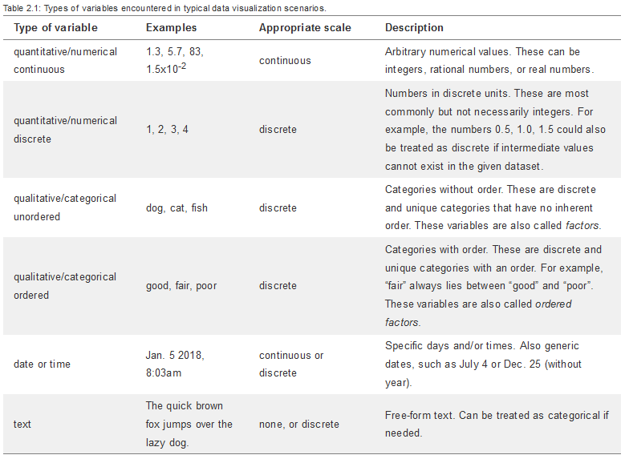

Wilke 2019 (Fundamentals of Data Visualisation)

## Choosing the right visual channel

How accurately can humans decode different visual encodings? (Cleveland & McGill 1984)

1. **Position along a common scale** (e.g., bar charts, scatterplots) 🏆 *Most accurate*
2. **Position on non-aligned scales** (e.g., stacked bar charts)
3. **Length, direction, angle** (e.g., pie charts)
4. **Area** (e.g., bubble charts)
5. **[Volume (3D space)](https://clauswilke.com/dataviz/no-3d.html), curvature (e.g., donut chart)**
6. **Shading, color saturation** 📉 *Least accurate*

➡️ **Key Takeaway:** Map your *most important* variable to position or length, not color or area!

⚠️ The `ggplot2` Bubble Chart Trap

In `ggplot2`, the aesthetic is called `size` (`aes(size = var)`). But by default, this scales the **radius** of the point, not the **area**. If your value doubles, the point looks four times as large!

**The fix:** Always add `+ scale_size_area()` to your bubble charts so the perceived area matches the data.

## Core Principles of Good Design

- 🖋️ Data-Ink Ratio
- 🎨 Color & Accessibility

> “Above all else show the data.” — [Edward Tufte](https://en.wikipedia.org/wiki/Edward_Tufte)
- **Maximize Data-Ink:** Ink used to present the actual data.
- **Erase Non-Data-Ink:** Gridlines, heavy borders, 3D effects, background colors.
- **Erase Redundant Data-Ink:** Ink that depicts the same information over and over.

Color should communicate information, not just decorate.

- **Sequential:** Ordered data (e.g., low to high density).
- **Diverging:** Ordered data with a critical midpoint (e.g., negative to positive).
- **Qualitative:** Categorical data (e.g., different continents).
- ⚠️ **Accessibility:** ~8% of men are colorblind. Always use colorblind-safe palettes (e.g., *Viridis*, *Okabe-Ito*).

## Application 1

Try to analyze the [famous visualization by Hans Rosling (“Gapminder”)](https://www.gapminder.org/tag/gapminder-world/) in groups of two. Please click on the link to enlarge.

[figure not shown]

**[1] The “Why” (Purpose):** What is the main story this graph is trying to tell?

**[2] The “What” (Data):** What data variables can you identify in the plot?

**[3] The “How” (Mapping):** How does the graph use visual properties to represent these variables?

`10:00`

## Application 2

Try to analyze this datajournalism visualization from the German newspaper Die ZEIT in groups of two.

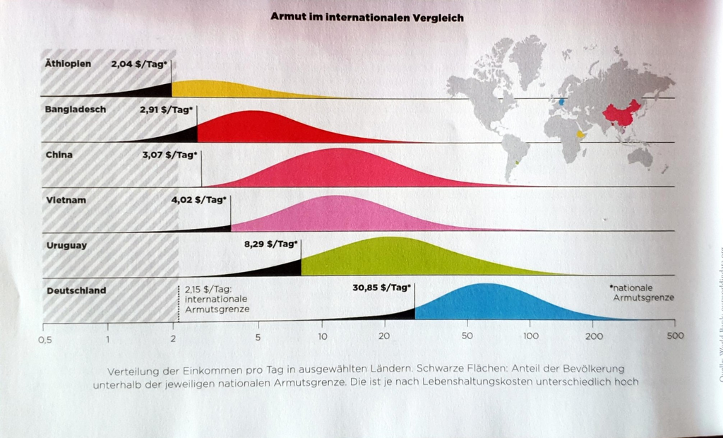

**[1] The “Why” (Purpose):** What is the main story this graph is trying to tell?

**[2] The “What” (Data):** What data variables can you identify in the plot?

**[3] The “How” (Mapping):** How does the graph use visual properties to represent these variables?

`05:00`

## Application 3: Design Critique (The Economist)

*The Economist* occasionally publishes [articles critiquing their own past chart designs](https://medium.com/the-economist/mistakes-weve-drawn-a-few-8cdd8a42d368). Look at this example of “Choosing the wrong visualization method.”

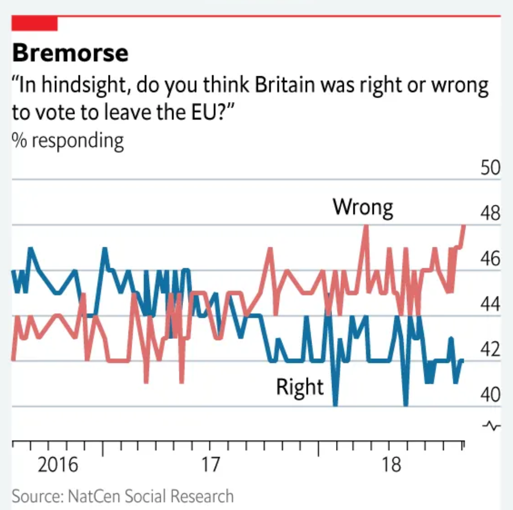

**[1] Perceptual Problems:** Based on Cleveland & McGill’s rankings, why is this specific visualization method failing the reader?

**[2] Improvements:** If you were the data editor, which visual channel (e.g., position, length) would you use to redesign this chart?

**[3] Tufte Test:** Is there any “non-data-ink” here that is making the chart harder to read than it needs to be?

`10:00`

## The “Perfect” Chart with Flawed Data

- 📊 The Chart
- 🔍 Flaws

Let’s look at another chart from [*The Economist*](https://medium.com/the-economist/the-challenges-of-charting-regional-inequality-a9376718348). Visually, this is a very well-designed “dumbbell plot.” It uses position along a common scale (Cleveland & McGill’s #1 ranking).

**But it was still retracted for being highly misleading. Why?**

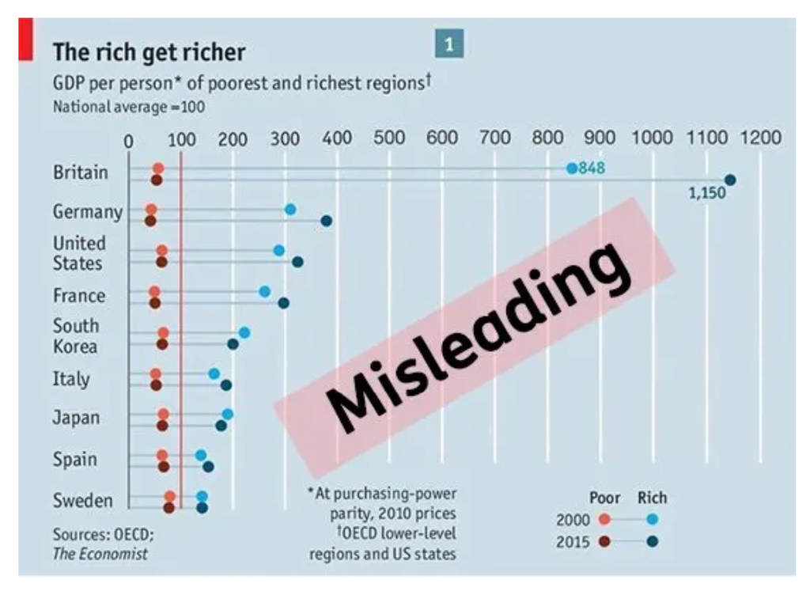

- **Visualisation:** The design is great. The data-ink ratio is solid.
- **Data:** It compares apples to oranges.
- **Flaws:** For the UK, it isolates the “City of London” (a tiny financial district with massive corporate wealth and almost zero residents) and compares it to entire U.S. states.
- ➡️ **Lessons:** A perfect Grammar of Graphics cannot save you if you don’t understand how your data is aggregated.

# AI & Data Visualisation

## Have you used AI for writing code?

Discuss in pairs of two.

**[1]** Have you used ChatGPT, Claude, Copilot, or similar tools to write R or ggplot2 code? Which tools did you use specifically? Web interface vs. CLI?

**[2]** Did the output look right to you? Did you run it as-is, or check it first?

**[3]** Did you ever get code that ran without errors — but produced something unexpected?

**[4]** Can you showcase some examples of code fully written by you vs. code written by an LLM?

**[5]** If you have generated data visualisations using LLMs, Was the output visually convincing?

`10:00`

## Misleading Graphs: Human Bias vs. AI Error

### 🧑‍💻 Human Error

*Visual Manipulation*

- Truncated y-axes (starting at 50 instead of 0)
- 3D pie charts distorting proportions
- Misleading aspect ratios
- Cherry-picked timelines

Intentional agenda or dataviz literacy

### 🤖 AI Error

*(Mostly) silent statistical errors*

- Plausible but incorrect `ggplot` statistics
- Grouping by the wrong variable
- Dropping `NA` values silently
- Mapping aesthetics incorrectly

Error hidden in seemingly perfect code

## What AI is actually good at — and where the real risk is

✅ **Producing executable code is essentially a solved problem**

Frontier models produce runnable visualisation code at >97% success rates on simple, structured queries.

❌ **The real risk: code that runs, produces a chart, and shows the wrong statistic**

The failure is invisible unless you already know your data.

**[Text2Vis (EMNLP 2025)](https://aclanthology.org/2025.emnlp-main.1622.pdf)** — GPT-4o, tested on diverse natural-language visualisation queries generating **Python** code (Matplotlib, seaborn):

- **87%** of outputs execute without error
- **42%** execute *and* show the correct statistic
- **26%** execute, show the correct statistic, *and* are visually appropriate

Python is the language LLMs have seen most of in training — it dominates Stack Overflow, Kaggle, and public tutorials. **R/ggplot2 has no equivalent benchmark** — and performance is likely no better: there is simply less training data for ggplot2 code than for Python visualisation libraries.

## Application 4: Prompting AI for simple charts

- 💻 Data
- 🤖 Prompt
- 🔍 Results

Open RStudio and create a new script. Copy and paste this exact code to create a custom dataset representing a survey of 10 people.

```r
library(ggplot2)
library(dplyr)

survey_data <- structure(list(
  Region = c("North", "North", "North", "North", "North",
             "North", "North", "North", "South", "South"),
  Trust_in_Gov = c(45, 50, 42, 48, 55, 40, 47, 49, 44, 48)),
  class = "data.frame", row.names = c(NA, -10L))
```

Open ChatGPT, Claude, or your preferred LLM. Give it the following prompt, then run the plotting code it gives you.

Copy and paste this prompt:

> I have an R dataframe called survey_data with two columns: Region and Trust_in_Gov. Please write ggplot2 code to create a bar chart showing the Trust in Government by Region.”

`05:00`

Discuss: Look at the chart you just generated. Did the AI get anything wrong?

- Did your AI use geom_col() or geom_bar(stat=“identity”) in its first code block?
- If so, it stacked (summed) the data. The North has a total score of 376, while the South has 92.
- The chart implies the North is 4x more trusting, but the average trust for both regions is actually almost identical (~47 for North, 46 for South).
- ➡️ LLMs often guess the simplest syntax first. You must know the Grammar of Graphics to evaluate the LLM’s output.

## “Does this chart show what I think it shows?”

> *“New learners are at greatest risk — plausible-looking code can build bad habits.”*

> — Mine Çetinkaya-Rundel (tidyverse team, April 2025)

A one-word difference in ggplot2:

- `geom_bar(stat = "count")` — plots the **number of rows** in each group
- `geom_bar(stat = "identity")` — plots **the value in a column**

➡️ **The grammar of graphics is what makes AI output auditable.**

Understanding the structure of a plot — data, aesthetics, statistics — is the skill that lets you catch these errors.

## Where the R community stands

- **Hadley Wickham** (useR! 2025: *“I wrote this talk with an LLM”*) — programmatic use via [`ellmer`](https://ellmer.tidyverse.org/): calling models from R code, not natural-language-to-chart
- **Joe Cheng** (Posit CTO, *“Keeping LLMs in Their Lane”*) — purpose-built, constrained tools are safer than open-ended LLM chat for analysis
- **Kieran Healy** (Posit conf 2025 closing keynote, *“Trustworthy Data Visualization”*) — trustworthiness requires social commitment, not automation; AI confabulation is an integrity question
- **R Consortium** — launched R+AI 2025 (November 2025); pragmatic institutional embrace

Classroom policies vary — some instructors prefer a no-AI approach when building foundational skills.

➡️ Our seminar:

- rely on AI both to improve and adapt code to your purpose and to help you understand the code
- but: understanding the code is essential!

## Disclosing AI usage

- ❌ *“AI tools were used in the preparation of this manuscript”* — generic, unverifiable, not sufficient
- ✅ Tool · provider · version when available · approximate date · task · degree of human oversight
- **70%** of ~5400 academic Q1 journals now have AI policies requiring transparency *([He & Bu, PNAS 2026](https://www.pnas.org/doi/10.1073/pnas.2526734123))* (as of Jan 2025)
- actual AI disclosure rate in published papers is only **~0.1%**. But: upward trend (0.43% in the first quarter of 2025)

Add a comment to your code file as you work — not at submission time:

`# AI: Claude Sonnet 5.5 (Anthropic, 2027-11-01) — grouped bar chart of X by Y — reviewed by author`

## AI as a quality check

- AI as low-cost error-checking tool
- responsibility to use AI to review code before publication to catch avoidable errors?
- After writing or generating visualisation code, ask an AI: *“What statistic does this chart actually display? Is anything wrong with the aggregation or data transformation?”*
- Compare the AI’s description with what you intended

➡️ The AI acts as your rigorous first reviewer, but you remain the final editor

## Our position for this workshop

1️⃣ AI tools are genuinely useful

2️⃣ Understanding the grammar of graphics is what lets you **evaluate** AI output

3️⃣ You are responsible for what your chart claims, regardless of how the code was written

4️⃣ To design a truly beautiful chart, you have to know clearly how you want it to look like - general purpose LLMs are not (yet?) trained on producing stunningly beautiful data visualisations

## A few great people working on ggplot2 and data visualisation

- [Thomas Lin Pedersen](https://github.com/thomasp85)
- [Cedric Scherer](https://github.com/Z3tt/)
- [Rohan Alexander](https://tellingstorieswithdata.com/)
- [Allison Horst](https://github.com/allisonhorst)
- [Andrew Heiss](https://datavizf23.classes.andrewheiss.com/)
- [Winston Chang](https://r-graphics.org/)

➡️ workshop material heavily draws on their excellent workshops and practical materials

# Questions? 🙋 🙋‍♂️

# Thanks for your attention.

[figure not shown]